# Optimal Treatment Analysis

## Outcome Variable

**Outcome Variable:** ever_stunted

## Predictor Variables

**Intervention Variable:** hfoodsec

**Adjustment Set:**

- arm
- sex
- W_mage
- meducyrs
- feducyrs
- hhwealth_quart
- vagbrth
- W_nrooms
- W_nchldlt5
- brthmon
- W_parity
- impfloor
- impsan
- safeh20
- delta_W_mage
- delta_meducyrs
- delta_feducyrs
- delta_hhwealth_quart
- delta_vagbrth
- delta_W_nrooms
- delta_W_nchldlt5
- delta_brthmon
- delta_W_parity
- delta_impfloor
- delta_impsan
- delta_safeh20

## Stratifying Variables

The analysis was stratified on these variable(s):

- agecat
- studyid
- country

## Data Summary

| agecat | studyid | country | hfoodsec | ever_stunted | n_cell | n |
| --- | --- | --- | --- | --- | --- | --- |
| 0-24 months | ki0047075b-MAL-ED | BANGLADESH | Food Secure | 0 | 62 | 194 |
| 0-24 months | ki0047075b-MAL-ED | BANGLADESH | Food Secure | 1 | 99 | 194 |
| 0-24 months | ki0047075b-MAL-ED | BANGLADESH | Mildly Food Insecure | 0 | 1 | 194 |
| 0-24 months | ki0047075b-MAL-ED | BANGLADESH | Mildly Food Insecure | 1 | 3 | 194 |
| 0-24 months | ki0047075b-MAL-ED | BANGLADESH | Food Insecure | 0 | 10 | 194 |
| 0-24 months | ki0047075b-MAL-ED | BANGLADESH | Food Insecure | 1 | 19 | 194 |
| 0-24 months | ki0047075b-MAL-ED | BRAZIL | Food Secure | 0 | 3 | 129 |
| 0-24 months | ki0047075b-MAL-ED | BRAZIL | Food Secure | 1 | 0 | 129 |
| 0-24 months | ki0047075b-MAL-ED | BRAZIL | Mildly Food Insecure | 0 | 7 | 129 |
| 0-24 months | ki0047075b-MAL-ED | BRAZIL | Mildly Food Insecure | 1 | 4 | 129 |
| 0-24 months | ki0047075b-MAL-ED | BRAZIL | Food Insecure | 0 | 90 | 129 |
| 0-24 months | ki0047075b-MAL-ED | BRAZIL | Food Insecure | 1 | 25 | 129 |
| 0-24 months | ki0047075b-MAL-ED | INDIA | Food Secure | 0 | 67 | 212 |
| 0-24 months | ki0047075b-MAL-ED | INDIA | Food Secure | 1 | 123 | 212 |
| 0-24 months | ki0047075b-MAL-ED | INDIA | Mildly Food Insecure | 0 | 5 | 212 |
| 0-24 months | ki0047075b-MAL-ED | INDIA | Mildly Food Insecure | 1 | 0 | 212 |
| 0-24 months | ki0047075b-MAL-ED | INDIA | Food Insecure | 0 | 7 | 212 |
| 0-24 months | ki0047075b-MAL-ED | INDIA | Food Insecure | 1 | 10 | 212 |
| 0-24 months | ki0047075b-MAL-ED | NEPAL | Food Secure | 0 | 63 | 128 |
| 0-24 months | ki0047075b-MAL-ED | NEPAL | Food Secure | 1 | 31 | 128 |
| 0-24 months | ki0047075b-MAL-ED | NEPAL | Mildly Food Insecure | 0 | 9 | 128 |
| 0-24 months | ki0047075b-MAL-ED | NEPAL | Mildly Food Insecure | 1 | 6 | 128 |
| 0-24 months | ki0047075b-MAL-ED | NEPAL | Food Insecure | 0 | 9 | 128 |
| 0-24 months | ki0047075b-MAL-ED | NEPAL | Food Insecure | 1 | 10 | 128 |
| 0-24 months | ki0047075b-MAL-ED | PERU | Food Secure | 0 | 6 | 113 |
| 0-24 months | ki0047075b-MAL-ED | PERU | Food Secure | 1 | 21 | 113 |
| 0-24 months | ki0047075b-MAL-ED | PERU | Mildly Food Insecure | 0 | 8 | 113 |
| 0-24 months | ki0047075b-MAL-ED | PERU | Mildly Food Insecure | 1 | 21 | 113 |
| 0-24 months | ki0047075b-MAL-ED | PERU | Food Insecure | 0 | 17 | 113 |
| 0-24 months | ki0047075b-MAL-ED | PERU | Food Insecure | 1 | 40 | 113 |

[output cut: 168 more lines]

The following strata were considered:

- agecat: 0-24 months, studyid: ki0047075b-MAL-ED, country: BANGLADESH
- agecat: 0-24 months, studyid: ki0047075b-MAL-ED, country: BRAZIL
- agecat: 0-24 months, studyid: ki0047075b-MAL-ED, country: INDIA
- agecat: 0-24 months, studyid: ki0047075b-MAL-ED, country: NEPAL
- agecat: 0-24 months, studyid: ki0047075b-MAL-ED, country: PERU
- agecat: 0-24 months, studyid: ki0047075b-MAL-ED, country: SOUTH AFRICA
- agecat: 0-24 months, studyid: ki1017093-NIH-Birth, country: BANGLADESH
- agecat: 0-24 months, studyid: ki1017093c-NIH-Crypto, country: BANGLADESH
- agecat: 0-24 months, studyid: ki1113344-GMS-Nepal, country: NEPAL
- agecat: 0-24 months, studyid: kiGH5241-JiVitA-3, country: BANGLADESH
- agecat: 0-24 months, studyid: kiGH5241-JiVitA-4, country: BANGLADESH
- agecat: 0-6 months, studyid: ki0047075b-MAL-ED, country: BANGLADESH
- agecat: 0-6 months, studyid: ki0047075b-MAL-ED, country: BRAZIL
- agecat: 0-6 months, studyid: ki0047075b-MAL-ED, country: INDIA
- agecat: 0-6 months, studyid: ki0047075b-MAL-ED, country: NEPAL
- agecat: 0-6 months, studyid: ki0047075b-MAL-ED, country: PERU
- agecat: 0-6 months, studyid: ki0047075b-MAL-ED, country: SOUTH AFRICA
- agecat: 0-6 months, studyid: ki1017093-NIH-Birth, country: BANGLADESH
- agecat: 0-6 months, studyid: ki1017093c-NIH-Crypto, country: BANGLADESH
- agecat: 0-6 months, studyid: ki1113344-GMS-Nepal, country: NEPAL
- agecat: 0-6 months, studyid: kiGH5241-JiVitA-3, country: BANGLADESH
- agecat: 0-6 months, studyid: kiGH5241-JiVitA-4, country: BANGLADESH
- agecat: 6-24 months, studyid: ki0047075b-MAL-ED, country: BANGLADESH
- agecat: 6-24 months, studyid: ki0047075b-MAL-ED, country: BRAZIL
- agecat: 6-24 months, studyid: ki0047075b-MAL-ED, country: INDIA
- agecat: 6-24 months, studyid: ki0047075b-MAL-ED, country: NEPAL
- agecat: 6-24 months, studyid: ki0047075b-MAL-ED, country: PERU
- agecat: 6-24 months, studyid: ki0047075b-MAL-ED, country: SOUTH AFRICA
- agecat: 6-24 months, studyid: ki1017093-NIH-Birth, country: BANGLADESH
- agecat: 6-24 months, studyid: ki1017093c-NIH-Crypto, country: BANGLADESH
- agecat: 6-24 months, studyid: ki1113344-GMS-Nepal, country: NEPAL
- agecat: 6-24 months, studyid: kiGH5241-JiVitA-3, country: BANGLADESH
- agecat: 6-24 months, studyid: kiGH5241-JiVitA-4, country: BANGLADESH

### Dropped Strata

Some strata were dropped due to rare outcomes:

- agecat: 0-24 months, studyid: ki0047075b-MAL-ED, country: BANGLADESH
- agecat: 0-24 months, studyid: ki0047075b-MAL-ED, country: BRAZIL
- agecat: 0-24 months, studyid: ki0047075b-MAL-ED, country: INDIA
- agecat: 0-6 months, studyid: ki0047075b-MAL-ED, country: BANGLADESH
- agecat: 0-6 months, studyid: ki0047075b-MAL-ED, country: BRAZIL
- agecat: 0-6 months, studyid: ki0047075b-MAL-ED, country: INDIA
- agecat: 0-6 months, studyid: ki0047075b-MAL-ED, country: NEPAL
- agecat: 0-6 months, studyid: ki0047075b-MAL-ED, country: SOUTH AFRICA
- agecat: 6-24 months, studyid: ki0047075b-MAL-ED, country: BANGLADESH
- agecat: 6-24 months, studyid: ki0047075b-MAL-ED, country: BRAZIL
- agecat: 6-24 months, studyid: ki0047075b-MAL-ED, country: INDIA
- agecat: 6-24 months, studyid: ki0047075b-MAL-ED, country: NEPAL

## Methods Detail

We’re interested in the causal parameters $E[Y_a]$ for all values of $a \in \mathcal{A}$. These parameters represent the mean outcome if, possibly contrary to fact, we intervened to set all units to have $A=a$. Under the randomization and positivity assumptions, these are identified by the statistical parameters $\psi_a=E_W[E_{Y|A,W}(Y|A=a,W)]$. In addition, we’re interested in the mean of $Y$, $E[Y]$ under no intervention (the observed mean). We will estimate these parameters by using SuperLearner to fit the relevant likelihood factors – $E_{Y|A,W}(Y|A=a,W)$ and $p(A=a|W)$, and then updating our likelihood fit using a joint TMLE.

For unadjusted analyses ($W=\{\}$), initial likelihoods were estimated using Lrnr_glm to estimate the simple $E(Y|A)$ and Lrnr_mean to estimate $p(A)$. For adjusted analyses, a small library containing Lrnr_glmnet, Lrnr_xgboost, and Lrnr_mean was used.

Having estimated these parameters, we will then use the delta method to estimate relative risks and attributable risks relative to a prespecified baseline level of $A$.

# Results Detail

## Results Plots

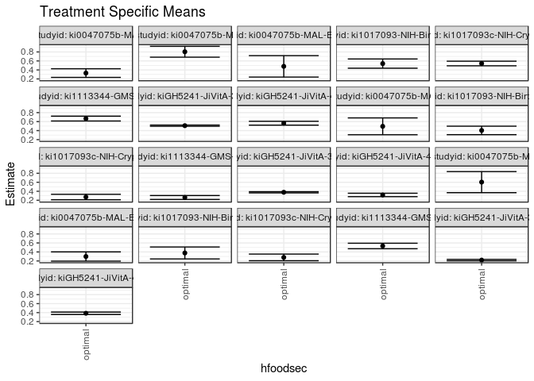

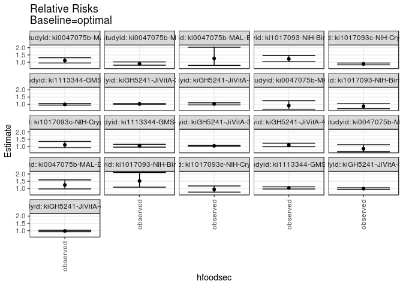

## Results Table

### Parameter: TSM

| agecat | studyid | country | intervention_level | baseline_level | estimate | ci_lower | ci_upper |
| --- | --- | --- | --- | --- | --- | --- | --- |
| 0-24 months | ki0047075b-MAL-ED | NEPAL | optimal | NA | 0.3299795 | 0.2341141 | 0.4258449 |
| 0-24 months | ki0047075b-MAL-ED | PERU | optimal | NA | 0.8042812 | 0.6838810 | 0.9246813 |
| 0-24 months | ki0047075b-MAL-ED | SOUTH AFRICA | optimal | NA | 0.4796013 | 0.2412410 | 0.7179616 |
| 0-24 months | ki1017093-NIH-Birth | BANGLADESH | optimal | NA | 0.5409356 | 0.4382532 | 0.6436181 |
| 0-24 months | ki1017093c-NIH-Crypto | BANGLADESH | optimal | NA | 0.5430536 | 0.4916091 | 0.5944982 |
| 0-24 months | ki1113344-GMS-Nepal | NEPAL | optimal | NA | 0.6672758 | 0.6134078 | 0.7211438 |
| 0-24 months | kiGH5241-JiVitA-3 | BANGLADESH | optimal | NA | 0.5097499 | 0.4961787 | 0.5233211 |
| 0-24 months | kiGH5241-JiVitA-4 | BANGLADESH | optimal | NA | 0.5646171 | 0.5211992 | 0.6080349 |
| 0-6 months | ki0047075b-MAL-ED | PERU | optimal | NA | 0.4948784 | 0.3077330 | 0.6820238 |
| 0-6 months | ki1017093-NIH-Birth | BANGLADESH | optimal | NA | 0.4039008 | 0.3094946 | 0.4983070 |
| 0-6 months | ki1017093c-NIH-Crypto | BANGLADESH | optimal | NA | 0.2724487 | 0.2117034 | 0.3331939 |
| 0-6 months | ki1113344-GMS-Nepal | NEPAL | optimal | NA | 0.2622974 | 0.2192945 | 0.3053003 |
| 0-6 months | kiGH5241-JiVitA-3 | BANGLADESH | optimal | NA | 0.3775175 | 0.3643140 | 0.3907210 |
| 0-6 months | kiGH5241-JiVitA-4 | BANGLADESH | optimal | NA | 0.3181866 | 0.2800264 | 0.3563468 |
| 6-24 months | ki0047075b-MAL-ED | PERU | optimal | NA | 0.6035047 | 0.3690738 | 0.8379357 |
| 6-24 months | ki0047075b-MAL-ED | SOUTH AFRICA | optimal | NA | 0.2986965 | 0.1960669 | 0.4013261 |
| 6-24 months | ki1017093-NIH-Birth | BANGLADESH | optimal | NA | 0.3774022 | 0.2447334 | 0.5100711 |
| 6-24 months | ki1017093c-NIH-Crypto | BANGLADESH | optimal | NA | 0.2786363 | 0.2049569 | 0.3523157 |
| 6-24 months | ki1113344-GMS-Nepal | NEPAL | optimal | NA | 0.5325742 | 0.4715189 | 0.5936295 |
| 6-24 months | kiGH5241-JiVitA-3 | BANGLADESH | optimal | NA | 0.2189274 | 0.2032632 | 0.2345916 |
| 6-24 months | kiGH5241-JiVitA-4 | BANGLADESH | optimal | NA | 0.3854084 | 0.3583395 | 0.4124772 |

### Parameter: E(Y)

| agecat | studyid | country | intervention_level | baseline_level | estimate | ci_lower | ci_upper |
| --- | --- | --- | --- | --- | --- | --- | --- |
| 0-24 months | ki0047075b-MAL-ED | NEPAL | observed | NA | 0.3671875 | 0.2833521 | 0.4510229 |
| 0-24 months | ki0047075b-MAL-ED | PERU | observed | NA | 0.7256637 | 0.6430317 | 0.8082957 |
| 0-24 months | ki0047075b-MAL-ED | SOUTH AFRICA | observed | NA | 0.6051502 | 0.5422501 | 0.6680504 |
| 0-24 months | ki1017093-NIH-Birth | BANGLADESH | observed | NA | 0.6645469 | 0.6276196 | 0.7014742 |
| 0-24 months | ki1017093c-NIH-Crypto | BANGLADESH | observed | NA | 0.4775726 | 0.4419904 | 0.5131548 |
| 0-24 months | ki1113344-GMS-Nepal | NEPAL | observed | NA | 0.6678082 | 0.6295756 | 0.7060408 |
| 0-24 months | kiGH5241-JiVitA-3 | BANGLADESH | observed | NA | 0.5232725 | 0.5136886 | 0.5328564 |
| 0-24 months | kiGH5241-JiVitA-4 | BANGLADESH | observed | NA | 0.5813264 | 0.5653125 | 0.5973403 |
| 0-6 months | ki0047075b-MAL-ED | PERU | observed | NA | 0.4513274 | 0.3591676 | 0.5434872 |
| 0-6 months | ki1017093-NIH-Birth | BANGLADESH | observed | NA | 0.3497615 | 0.3124631 | 0.3870600 |
| 0-6 months | ki1017093c-NIH-Crypto | BANGLADESH | observed | NA | 0.3021108 | 0.2694011 | 0.3348205 |
| 0-6 months | ki1113344-GMS-Nepal | NEPAL | observed | NA | 0.2739726 | 0.2377697 | 0.3101755 |
| 0-6 months | kiGH5241-JiVitA-3 | BANGLADESH | observed | NA | 0.3935789 | 0.3847652 | 0.4023927 |
| 0-6 months | kiGH5241-JiVitA-4 | BANGLADESH | observed | NA | 0.3483896 | 0.3331073 | 0.3636720 |
| 6-24 months | ki0047075b-MAL-ED | PERU | observed | NA | 0.5081967 | 0.3816986 | 0.6346949 |
| 6-24 months | ki0047075b-MAL-ED | SOUTH AFRICA | observed | NA | 0.3724138 | 0.2934521 | 0.4513755 |
| 6-24 months | ki1017093-NIH-Birth | BANGLADESH | observed | NA | 0.5739130 | 0.5216565 | 0.6261696 |
| 6-24 months | ki1017093c-NIH-Crypto | BANGLADESH | observed | NA | 0.2628458 | 0.2244546 | 0.3012371 |
| 6-24 months | ki1113344-GMS-Nepal | NEPAL | observed | NA | 0.5542169 | 0.5063374 | 0.6020964 |
| 6-24 months | kiGH5241-JiVitA-3 | BANGLADESH | observed | NA | 0.2172338 | 0.2078312 | 0.2266365 |
| 6-24 months | kiGH5241-JiVitA-4 | BANGLADESH | observed | NA | 0.3773167 | 0.3586399 | 0.3959936 |

### Parameter: RR

| agecat | studyid | country | intervention_level | baseline_level | estimate | ci_lower | ci_upper |
| --- | --- | --- | --- | --- | --- | --- | --- |
| 0-24 months | ki0047075b-MAL-ED | NEPAL | observed | optimal | 1.1127585 | 0.9466915 | 1.3079567 |
| 0-24 months | ki0047075b-MAL-ED | PERU | observed | optimal | 0.9022513 | 0.7972958 | 1.0210231 |
| 0-24 months | ki0047075b-MAL-ED | SOUTH AFRICA | observed | optimal | 1.2617776 | 0.7829031 | 2.0335629 |
| 0-24 months | ki1017093-NIH-Birth | BANGLADESH | observed | optimal | 1.2285138 | 1.0317321 | 1.4628276 |
| 0-24 months | ki1017093c-NIH-Crypto | BANGLADESH | observed | optimal | 0.8794206 | 0.8198616 | 0.9433062 |
| 0-24 months | ki1113344-GMS-Nepal | NEPAL | observed | optimal | 1.0007979 | 0.9495407 | 1.0548219 |
| 0-24 months | kiGH5241-JiVitA-3 | BANGLADESH | observed | optimal | 1.0265279 | 1.0067229 | 1.0467226 |
| 0-24 months | kiGH5241-JiVitA-4 | BANGLADESH | observed | optimal | 1.0295941 | 0.9600875 | 1.1041328 |
| 0-6 months | ki0047075b-MAL-ED | PERU | observed | optimal | 0.9119967 | 0.6662782 | 1.2483342 |
| 0-6 months | ki1017093-NIH-Birth | BANGLADESH | observed | optimal | 0.8659590 | 0.6988032 | 1.0730991 |
| 0-6 months | ki1017093c-NIH-Crypto | BANGLADESH | observed | optimal | 1.1088725 | 0.9137135 | 1.3457153 |
| 0-6 months | ki1113344-GMS-Nepal | NEPAL | observed | optimal | 1.0445112 | 0.9520283 | 1.1459783 |
| 0-6 months | kiGH5241-JiVitA-3 | BANGLADESH | observed | optimal | 1.0425449 | 1.0147575 | 1.0710932 |
| 0-6 months | kiGH5241-JiVitA-4 | BANGLADESH | observed | optimal | 1.0949224 | 0.9795278 | 1.2239112 |
| 6-24 months | ki0047075b-MAL-ED | PERU | observed | optimal | 0.8420758 | 0.6347013 | 1.1172052 |
| 6-24 months | ki0047075b-MAL-ED | SOUTH AFRICA | observed | optimal | 1.2467968 | 0.9742616 | 1.5955696 |
| 6-24 months | ki1017093-NIH-Birth | BANGLADESH | observed | optimal | 1.5206934 | 1.0967349 | 2.1085390 |
| 6-24 months | ki1017093c-NIH-Crypto | BANGLADESH | observed | optimal | 0.9433296 | 0.7553879 | 1.1780313 |
| 6-24 months | ki1113344-GMS-Nepal | NEPAL | observed | optimal | 1.0406378 | 0.9695804 | 1.1169028 |
| 6-24 months | kiGH5241-JiVitA-3 | BANGLADESH | observed | optimal | 0.9922642 | 0.9370381 | 1.0507453 |
| 6-24 months | kiGH5241-JiVitA-4 | BANGLADESH | observed | optimal | 0.9790051 | 0.9314099 | 1.0290323 |

### Parameter: PAR

| agecat | studyid | country | intervention_level | baseline_level | estimate | ci_lower | ci_upper |
| --- | --- | --- | --- | --- | --- | --- | --- |
| 0-24 months | ki0047075b-MAL-ED | NEPAL | optimal | NA | 0.0372080 | -0.0160933 | 0.0905093 |
| 0-24 months | ki0047075b-MAL-ED | PERU | optimal | NA | -0.0786174 | -0.1766132 | 0.0193783 |
| 0-24 months | ki0047075b-MAL-ED | SOUTH AFRICA | optimal | NA | 0.1255489 | -0.1026131 | 0.3537109 |
| 0-24 months | ki1017093-NIH-Birth | BANGLADESH | optimal | NA | 0.1236113 | 0.0298097 | 0.2174128 |
| 0-24 months | ki1017093c-NIH-Crypto | BANGLADESH | optimal | NA | -0.0654811 | -0.1031768 | -0.0277854 |
| 0-24 months | ki1113344-GMS-Nepal | NEPAL | optimal | NA | 0.0005324 | -0.0345468 | 0.0356116 |
| 0-24 months | kiGH5241-JiVitA-3 | BANGLADESH | optimal | NA | 0.0135226 | 0.0035865 | 0.0234587 |
| 0-24 months | kiGH5241-JiVitA-4 | BANGLADESH | optimal | NA | 0.0167094 | -0.0227254 | 0.0561441 |
| 0-6 months | ki0047075b-MAL-ED | PERU | optimal | NA | -0.0435510 | -0.1993530 | 0.1122511 |
| 0-6 months | ki1017093-NIH-Birth | BANGLADESH | optimal | NA | -0.0541393 | -0.1406101 | 0.0323316 |
| 0-6 months | ki1017093c-NIH-Crypto | BANGLADESH | optimal | NA | 0.0296622 | -0.0231373 | 0.0824616 |
| 0-6 months | ki1113344-GMS-Nepal | NEPAL | optimal | NA | 0.0116752 | -0.0126395 | 0.0359898 |
| 0-6 months | kiGH5241-JiVitA-3 | BANGLADESH | optimal | NA | 0.0160614 | 0.0058540 | 0.0262688 |
| 0-6 months | kiGH5241-JiVitA-4 | BANGLADESH | optimal | NA | 0.0302030 | -0.0052500 | 0.0656560 |
| 6-24 months | ki0047075b-MAL-ED | PERU | optimal | NA | -0.0953080 | -0.2690666 | 0.0784506 |
| 6-24 months | ki0047075b-MAL-ED | SOUTH AFRICA | optimal | NA | 0.0737173 | 0.0002175 | 0.1472171 |
| 6-24 months | ki1017093-NIH-Birth | BANGLADESH | optimal | NA | 0.1965108 | 0.0744188 | 0.3186028 |
| 6-24 months | ki1017093c-NIH-Crypto | BANGLADESH | optimal | NA | -0.0157904 | -0.0777144 | 0.0461335 |
| 6-24 months | ki1113344-GMS-Nepal | NEPAL | optimal | NA | 0.0216426 | -0.0159668 | 0.0592521 |
| 6-24 months | kiGH5241-JiVitA-3 | BANGLADESH | optimal | NA | -0.0016936 | -0.0142303 | 0.0108431 |
| 6-24 months | kiGH5241-JiVitA-4 | BANGLADESH | optimal | NA | -0.0080916 | -0.0273034 | 0.0111202 |

### Parameter: PAF

| agecat | studyid | country | intervention_level | baseline_level | estimate | ci_lower | ci_upper |
| --- | --- | --- | --- | --- | --- | --- | --- |
| 0-24 months | ki0047075b-MAL-ED | NEPAL | optimal | NA | 0.1013324 | -0.0563103 | 0.2354487 |
| 0-24 months | ki0047075b-MAL-ED | PERU | optimal | NA | -0.1083387 | -0.2542397 | 0.0205902 |
| 0-24 months | ki0047075b-MAL-ED | SOUTH AFRICA | optimal | NA | 0.2074673 | -0.2772973 | 0.5082523 |
| 0-24 months | ki1017093-NIH-Birth | BANGLADESH | optimal | NA | 0.1860083 | 0.0307561 | 0.3163925 |
| 0-24 months | ki1017093c-NIH-Crypto | BANGLADESH | optimal | NA | -0.1371123 | -0.2197180 | -0.0601012 |
| 0-24 months | ki1113344-GMS-Nepal | NEPAL | optimal | NA | 0.0007972 | -0.0531407 | 0.0519727 |
| 0-24 months | kiGH5241-JiVitA-3 | BANGLADESH | optimal | NA | 0.0258424 | 0.0066780 | 0.0446371 |
| 0-24 months | kiGH5241-JiVitA-4 | BANGLADESH | optimal | NA | 0.0287435 | -0.0415717 | 0.0943118 |
| 0-6 months | ki0047075b-MAL-ED | PERU | optimal | NA | -0.0964953 | -0.5008745 | 0.1989324 |
| 0-6 months | ki1017093-NIH-Birth | BANGLADESH | optimal | NA | -0.1547891 | -0.4310181 | 0.0681196 |
| 0-6 months | ki1017093c-NIH-Crypto | BANGLADESH | optimal | NA | 0.0981831 | -0.0944350 | 0.2569008 |
| 0-6 months | ki1113344-GMS-Nepal | NEPAL | optimal | NA | 0.0426144 | -0.0503890 | 0.1273832 |
| 0-6 months | kiGH5241-JiVitA-3 | BANGLADESH | optimal | NA | 0.0408087 | 0.0145429 | 0.0663744 |
| 0-6 months | kiGH5241-JiVitA-4 | BANGLADESH | optimal | NA | 0.0866933 | -0.0209001 | 0.1829473 |
| 6-24 months | ki0047075b-MAL-ED | PERU | optimal | NA | -0.1875416 | -0.5755443 | 0.1049093 |
| 6-24 months | ki0047075b-MAL-ED | SOUTH AFRICA | optimal | NA | 0.1979447 | -0.0264184 | 0.3732646 |
| 6-24 months | ki1017093-NIH-Birth | BANGLADESH | optimal | NA | 0.3424052 | 0.0882026 | 0.5257380 |
| 6-24 months | ki1017093c-NIH-Crypto | BANGLADESH | optimal | NA | -0.0600749 | -0.3238231 | 0.1511261 |
| 6-24 months | ki1113344-GMS-Nepal | NEPAL | optimal | NA | 0.0390509 | -0.0313740 | 0.1046669 |
| 6-24 months | kiGH5241-JiVitA-3 | BANGLADESH | optimal | NA | -0.0077961 | -0.0671925 | 0.0482946 |
| 6-24 months | kiGH5241-JiVitA-4 | BANGLADESH | optimal | NA | -0.0214452 | -0.0736411 | 0.0282132 |